# Sixth Week: Linear Models

House price prediction

Aryan Tajmirriahi

2018-04-13 23:56:27

> با توجه به داده های قیمت منازل لطفا با سوالات زیر پاسخ دهید.

در کل ای تمرین برای بالا رفتن دقت کل داده هایی که شرایط فروششان غیرنرمال بود را از مجموعه آموزشی خود حذف کردیم.

```r
library(readr)
library(dplyr)
```

```r
library(highcharter)
library(corrplot)
dic_var = read_delim("E://edu//TahlilDade//dictionnaire_variables.csv", delim = ";")
dic_nvx = read_csv("E://edu//TahlilDade//dictionnaire_niveaux.csv", col_names = c("variable", "label", "Type")) %>% select(1:3)
house = read_csv("E://edu//TahlilDade//train.csv")
house %>% filter(SaleCondition == "Normal") -> house
```

۱. ماتریس همبستگی متغیرهای مختلف را به دست آورده و سپس رسم نمایید. اعداد به دست آمده را با آزمون فرض معناداری همبستگی بسنجید و سپس ده متغیری که همبستگی بالاتری با قیمت دارند را مشخص نمایید.

```r
#1
house %>% select_if(is.numeric) -> house_num
cor_mat = cor(house_num, use = "pairwise.complete.obs")
cor_mat %>% View()
cor.mtest(cor_mat) -> cor_test

cbind.data.frame(cor_mat[,38], cor_test$p[,38]) -> final
colnames(final)[1] = 'corr'
colnames(final)[2] = 'pval'
final$name = rownames(final)
final %>% filter(pval < 0.05) %>% arrange(desc(corr)) %>% slice(2:11) %>% select(name) ->selected_cols
selected_cols
```

```
## # A tibble: 10 x 1
##    name
##    <chr>
##  1 OverallQual
##  2 GrLivArea
##  3 TotalBsmtSF
##  4 GarageCars
##  5 1stFlrSF
##  6 GarageArea
##  7 FullBath
##  8 TotRmsAbvGrd
##  9 YearBuilt
## 10 YearRemodAdd
```

۲. در یک تصویر نمودار پراکنش دو به دو ده متغیر بدست آمده به همراه قیمت را رسم نمایید و هم خطی بودن متغیرها را بررسی کنید

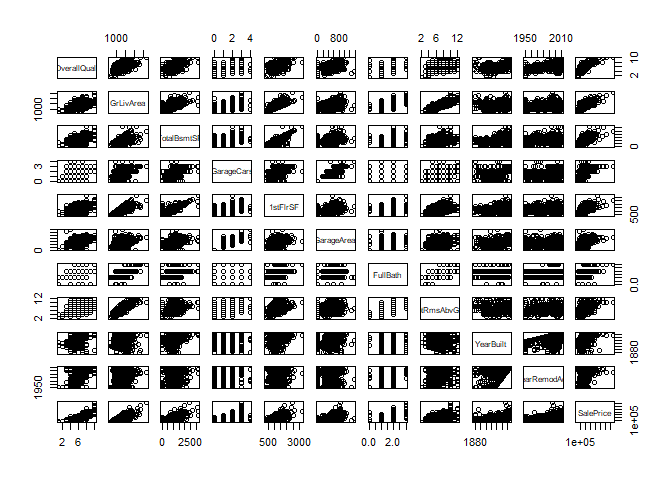

```r
#2
selected_cols = selected_cols$name
house %>% select(one_of(union(selected_cols, "SalePrice"))) -> n_house
pairs(n_house)
```

۳. یک مدل خطی بر اساس ده متغیر برای پیش بینی قیمت برازش دهید. و سپس خلاصه نتایج مدل را به دست آورید.

```r
#3
fit = lm(SalePrice ~OverallQual + GrLivArea + GarageCars + GarageArea + TotalBsmtSF + FullBath + TotRmsAbvGrd + YearBuilt + YearRemodAdd + `1stFlrSF`,data = n_house)
summary(fit)
```

```
##
## Call:
## lm(formula = SalePrice ~ OverallQual + GrLivArea + GarageCars +
##     GarageArea + TotalBsmtSF + FullBath + TotRmsAbvGrd + YearBuilt +
##     YearRemodAdd + `1stFlrSF`, data = n_house)
##
## Residuals:
##     Min      1Q  Median      3Q     Max
## -101030  -16591    -844   14396  259730
##
## Coefficients:
##                Estimate Std. Error t value Pr(>|t|)
## (Intercept)  -1.194e+06  1.067e+05 -11.181  < 2e-16 ***
## OverallQual   1.543e+04  9.839e+02  15.683  < 2e-16 ***
## GrLivArea     7.324e+01  3.738e+00  19.596  < 2e-16 ***
## GarageCars    2.226e+03  2.605e+03   0.854 0.393100
## GarageArea    3.103e+01  8.825e+00   3.516 0.000455 ***
## TotalBsmtSF   3.190e+01  3.595e+00   8.873  < 2e-16 ***
## FullBath     -1.055e+04  2.303e+03  -4.582 5.10e-06 ***
## TotRmsAbvGrd -4.280e+03  9.669e+02  -4.426 1.05e-05 ***
## YearBuilt     2.865e+02  4.072e+01   7.034 3.37e-12 ***
## YearRemodAdd  2.950e+02  5.122e+01   5.759 1.08e-08 ***
## `1stFlrSF`    9.295e+00  4.137e+00   2.247 0.024835 *
## ---
## Signif. codes:  0 '***' 0.001 '**' 0.01 '*' 0.05 '.' 0.1 ' ' 1
##
## Residual standard error: 28450 on 1187 degrees of freedom
## Multiple R-squared:  0.8349, Adjusted R-squared:  0.8335
## F-statistic: 600.2 on 10 and 1187 DF,  p-value: < 2.2e-16
```

۴. نمودار قیمت واقعی و قیمت پیش بینی را رسم نمایید و خوب بودن مدل را ارزیابی کنید.

چنانچه در نمودار پیداست مدل نسبتا خوبی داریم که تقریبا بر خط همانی مستقر است.

```r
#4
n_house$predicted_price = predict(fit)
n_house %>% hchart("point", hcaes(x = predicted_price, y = SalePrice))
```

[interactive chart not shown]

۵. مقدار R-squared مدل را به دست آورید. آیا بر اساس این کمیت مدل به خوبی به داده ها برازش داده شده است؟ کمیت F-statistic را در خلاصه مدل تفسیر نمایید.

در این سوال فقط مقدار R-squared حساب شده است.

```r
#5
sstot = sum((n_house$SalePrice - mean(n_house$SalePrice))^2)
ssres = sum((n_house$SalePrice - n_house$predicted_price)^2)
1 - ssres / sstot
```

```
## [1] 0.8348961
```

۶. بر اساس p-value سطح معناداری ضرایب تصمیم بگیرید که چه متغیرهایی در مدل سازی استفاده شود. بر اساس متغیرهای جدید دوباره مدل سازی کنید و نتایج رو گزارش دهید.

```r
data.frame(summary(fit)$coefficients)%>% filter(`Pr...t..` < 0.05)  %>% View()
fit = lm(SalePrice ~OverallQual + GrLivArea + GarageCars + TotalBsmtSF + FullBath + YearBuilt + YearRemodAdd + `1stFlrSF`,data = n_house)
summary(fit)
```

```
##
## Call:
## lm(formula = SalePrice ~ OverallQual + GrLivArea + GarageCars +
##     TotalBsmtSF + FullBath + YearBuilt + YearRemodAdd + `1stFlrSF`,
##     data = n_house)
##
## Residuals:
##    Min     1Q Median     3Q    Max
## -96174 -16309  -1138  14207 274815
##
## Coefficients:
##                Estimate Std. Error t value Pr(>|t|)
## (Intercept)  -1.250e+06  1.073e+05 -11.647  < 2e-16 ***
## OverallQual   1.573e+04  9.943e+02  15.817  < 2e-16 ***
## GrLivArea     6.256e+01  2.767e+00  22.612  < 2e-16 ***
## GarageCars    9.538e+03  1.571e+03   6.070 1.72e-09 ***
## TotalBsmtSF   3.299e+01  3.637e+00   9.071  < 2e-16 ***
## FullBath     -1.271e+04  2.301e+03  -5.521 4.13e-08 ***
## YearBuilt     3.037e+02  4.111e+01   7.387 2.81e-13 ***
## YearRemodAdd  3.006e+02  5.185e+01   5.798 8.59e-09 ***
## `1stFlrSF`    1.082e+01  4.175e+00   2.593  0.00964 **
## ---
## Signif. codes:  0 '***' 0.001 '**' 0.01 '*' 0.05 '.' 0.1 ' ' 1
##
## Residual standard error: 28820 on 1189 degrees of freedom
## Multiple R-squared:  0.8302, Adjusted R-squared:  0.8291
## F-statistic: 726.7 on 8 and 1189 DF,  p-value: < 2.2e-16
```

۷. مدل خود را بر اساس باقی مانده نقص یابی کنید. سه محک normality, independance, Constant Variance را در نقص یابی خود در نظر بگیرید.

در این سوال برای Constatnt variance صرفا نمودار کشیدیم و مشخصا مقدار ثابت نیست و برای independence از تست vif و برای normality از تست qqplot استفاده شد.

```r
library(car)
shapiro.test(predict(fit))
```

```
##
##  Shapiro-Wilk normality test
##
## data:  predict(fit)
## W = 0.98519, p-value = 1.091e-09
```

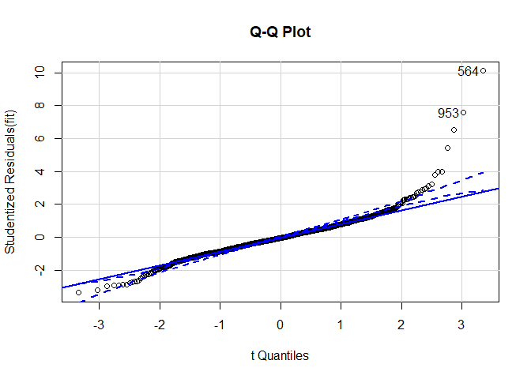

```
## [1] 564 953
```

```r
qqPlot(fit, id.method="identify", simulate = TRUE, main="Q-Q Plot")
```

```r
vif(fit)
```

```
##  OverallQual    GrLivArea   GarageCars  TotalBsmtSF     FullBath
##     2.475559     2.721652     1.792461     3.074602     2.192494
##    YearBuilt YearRemodAdd   `1stFlrSF`
##     2.118725     1.593023     3.156151
```

```r
hchart(n_house$SalePrice - n_house$predicted_price)
```

[interactive chart not shown]

۸. داده ها را به پنج قسمت تقسیم کنید. بر اساس چهار قسمت مدل خطی را بسازید و صحت مدل را برای یک قسمت باقی مانده را تست کنید. خطای پیش بینی شما چقدر است؟

```r
k = as.integer(0.8 * count(n_house))
n_house_train <- n_house %>% slice(1:k)
n_house_test <- n_house %>% slice(k : as.integer(count(n_house)))
fit = lm(SalePrice ~OverallQual + GrLivArea + GarageCars + TotalBsmtSF + FullBath + YearBuilt + YearRemodAdd + `1stFlrSF`,data = n_house_train)
n_house_test$predicted_price = predict(fit, n_house_test)
sqrt(mean((n_house_test$predicted_price - n_house_test$SalePrice)))
```

```
## [1] 53.60564
```

۹. آیا قیمت ربط غیر خطی با یکی از ده متغیر استفاده شده دارد؟ بر اساس دستاوردهای خود مدل را بهتر نمایید.

در این سوال همه پارامتر ها خطی بودند و فقط برخی بازه های ناخطیشان را عوض کردیم.

```r
selected_cols
```

```
##  [1] "OverallQual"  "GrLivArea"    "TotalBsmtSF"  "GarageCars"
##  [5] "1stFlrSF"     "GarageArea"   "FullBath"     "TotRmsAbvGrd"
##  [9] "YearBuilt"    "YearRemodAdd"
```

```r
n_house %>% group_by(OverallQual) %>% summarise(mean_price = mean(SalePrice)) %>% hchart("point", hcaes(x = OverallQual, y  = mean_price))
```

[interactive chart not shown]

```r
n_house %>% group_by(GrLivArea) %>% summarise(mean_price = mean(SalePrice)) %>% hchart("point", hcaes(x = GrLivArea, y  = mean_price))
```

[interactive chart not shown]

```r
n_house %>% group_by(GarageCars) %>% summarise(mean_price = mean(SalePrice)) %>% hchart("point", hcaes(x = GarageCars, y  = mean_price))
```

[interactive chart not shown]

```r
n_house %>% filter(GarageCars < 4)->n_house
n_house %>% group_by(GarageArea) %>% summarise(mean_price = mean(SalePrice)) %>% hchart("point", hcaes(x = GarageArea, y  = mean_price))
```

[interactive chart not shown]

```r
n_house %>% group_by(TotalBsmtSF) %>% summarise(mean_price = mean(SalePrice)) %>% hchart("point", hcaes(x = TotalBsmtSF, y  = mean_price))
```

[interactive chart not shown]

```r
n_house %>% group_by(`1stFlrSF`) %>% summarise(mean_price = mean(SalePrice)) %>% hchart("point", hcaes(x = `1stFlrSF`, y  = mean_price))
```

[interactive chart not shown]

```r
n_house %>% group_by(FullBath) %>% summarise(mean_price = mean(SalePrice)) %>% hchart("point", hcaes(x = FullBath, y  = mean_price))
```

[interactive chart not shown]

```r
n_house %>% filter(FullBath > 0) -> n_house
n_house %>% group_by(TotRmsAbvGrd) %>% summarise(mean_price = mean(SalePrice)) %>% hchart("point", hcaes(x = TotRmsAbvGrd, y  = mean_price))
```

[interactive chart not shown]

```r
n_house %>% group_by(YearBuilt) %>% summarise(mean_price = mean(SalePrice)) %>% hchart("point", hcaes(x = YearBuilt, y  = mean_price))
```

[interactive chart not shown]

```r
n_house %>% group_by(YearRemodAdd) %>% summarise(mean_price = mean(SalePrice)) %>% hchart("point", hcaes(x = YearRemodAdd, y  = mean_price))
```

[interactive chart not shown]

۱۰. بر اساس مدل نهایی به دست آمده نتایج پیش بینی خود را بر روی test.csv به دست آورید و در سایت kaggle در مسابقه House Prices: Advanced Regression Techniques بارگذاری نمایید. سپس لینک رتبه و عدد آن را ضمیمه تمرین کنید.

https://www.kaggle.com/c/house-prices-advanced-regression-techniques/team با خطای 0.61

```r
house_test = read_csv("E://edu//TahlilDade//test.csv")
house_test[is.na(house_test)] <- 0
fit = lm(SalePrice ~OverallQual + GrLivArea + GarageCars + TotalBsmtSF + FullBath + YearBuilt + YearRemodAdd + `1stFlrSF`,data = n_house_train)
house_test$SalePrice = predict(fit, house_test)
house_test %>% View()
house_test %>% select(Id, SalePrice) %>% write.csv("E://edu//TahlilDade//testans.csv", row.names = FALSE)
```